## Running virtual machine using the VMWare player.

This document is prepared for the data science lab users who are taking the class Introduction to Data Science at University of Nebraska at Omaha. The class website can be visited [here](http://www.unomaha.edu/mahbubulmajumder/data-science/fall-2014/index.html). For convenience, a Linux virtual machine is created where all the data science tools are configured for training purpose. You will need two things to be able to use this resource.

- Windows users need VMWare player to run the virtual machine. You can download VMWare player from [here](https://my.vmware.com/web/vmware/free#desktop_end_user_computing/vmware_player/6_0). MAC users need Virtual Box which can be downloaded from [here](https://www.virtualbox.org/wiki/Downloads).
- Data Science virtual machine datachienceVM. You can copy it from any of the lab machines.

The virtual machine is configured with the following tools

- R
- MySQL
- Hadoop

This document provides detailed instructions on how to work on the data science virtual machine. There will be seperate documentation on how to work with data science tools. If you have any question, please contact the course instructor [Dr. Mahbubul Majumder](http://www.unomaha.edu/mahbubulmajumder/index.html).

### Starting data science virtual machine

1. Enter into the lab machine by giving the password *training123*
2. Then we open up the VMWare player where we can use the LINUX commands in the terminal window of that machine. For that we click on the image on your task bar.
3. We then get the window giving us the options to select the required virtual machine we wanted to use. If you don’t find the virtual machine you are looking for in the list, you may need to open your machine from the option `Open a Virtual Machine`
4. To select a virtual machine we should double click on the name which opens the virtual machine. Open the **datascienceVM**
5. Now you need to enter the password of the virtual machine to open and use it. The password is *training123*
6. Now you are in the `datascienceVM` Virtual Machine where you will find all the commands on the left side task bar.
7. Now open the terminal window by giving a click on it. The terminal window looks like the following image.

[figure not shown]

8. After the terminal window is opened we now perform the following commands.

### Most Commonly used UNIX/LINUX commands

Contents

1. ls
2. pwd
3. cd
4. vi
5. ps
6. man
7. mkdir
8. rmdir
9. mv
10. cp
11. sudo
12. kill
13. head
14. tail
15. tar
16. who
17. cat
18. clear
19. rm
20. top
21. touch
22. grep
23. history
24. cal
25. apt
26. locate
27. free
28. passwd
29. pipe `|`
30. `>`
31. exit
1. `ls` command is used to display the contents that are present in your current working directory. When ever anyone wants to know the files and directories that are present in the current directory that he is working in then he uses this command. This is one of the most important and commonly used commands in the LINUX operating system.

   ```
   training@ubuntu:~$ ls
   Desktop    Downloads         mathlab  Pictures  R          test456
   Documents  examples.desktop  Music    Public    Templates  Videos
   ```

- There are several options while using `ls` command. Now if you provide `ls -l` the output will display information about the files. The following example presents us a more clear picture of the usage of the command.

  ```
  training@ubuntu:~$ ls -l
  total 52
  drwxr-xr-x 2 training training 4096 Oct 16 17:09 Desktop
  drwxr-xr-x 2 training training 4096 Oct 16 17:09 Documents
  drwxr-xr-x 3 training training 4096 Nov  4 12:18 Downloads
  ```

2. `pwd` [present working directory] as the name suggests it displays the pathname of the directory we are currently working in. This shows the exact place where we are performing the operations

   ```
   training@ubuntu:~$ pwd
   /home/training
   ```

3. `cd` command enables us to move from one place to another. The mostly and highly used command for each and every purpose is the `cd` command.

   ```
   training@ubuntu:~$ cd Downloads/
   training@ubuntu:~/Downloads$ ls
   hadoop-1.2.1  hadoop-1.2.1.tar.gz  jdk-8u25-linux-x64.tar.gz  rstudio-0.98.1087-amd64.deb
   training@ubuntu:~/Downloads$ cd hadoop-1.2.1/
   training@ubuntu:~/Downloads/hadoop-1.2.1$ ls
   bin          conf                  hadoop-client-1.2.1.jar       hadoop-test-1.2.1.jar   lib          NOTICE.txt  src
   build.xml    contrib               hadoop-core-1.2.1.jar         hadoop-tools-1.2.1.jar  libexec      README.txt  webapps
   c++          docs                  hadoop-examples-1.2.1.jar     ivy                     LICENSE.txt  sbin
   CHANGES.txt  hadoop-ant-1.2.1.jar  hadoop-minicluster-1.2.1.jar  ivy.xml                 logs         share
   training@ubuntu:~/Downloads/hadoop-1.2.1$
   ```

4. `vi` command is used to create a file. Whenever you wish to create a file then follow this syntax. Below is an example showing the syntax of creating any `text` file or a `C` file.

   ```
   vi [filename].txt which creates a Text file
   vi [filename].c   which creates a C file.
   ```

- you can create different kinds of files by giving their type properly after the file name. As you need to create a `C` file you extension should be `.c`
5. `ps` command displays the snapshot of currently running process. This also enables one to know much more information about the currently running process.

   ```
   training@ubuntu:~$ ps
     PID TTY          TIME CMD
    2903 pts/13   00:00:00 bash
    4483 pts/13   00:00:00 ps
   ```

6. `man` command that displays the help information of any particular commands we use. Lets see an example giving the command `man mkdir` which gives us the information about that command.

```
MKDIR(1)                                                   User Commands                                                  MKDIR(1)

NAME
       mkdir - make directories

SYNOPSIS
       mkdir [OPTION]... DIRECTORY...

DESCRIPTION
       Create the DIRECTORY(ies), if they do not already exist.

       Mandatory arguments to long options are mandatory for short options too.
       -m, --mode=MODE
              set file mode (as in chmod), not a=rwx - umask
       -p, --parents
              no error if existing, make parent directories as needed
       -v, --verbose
:
```

7. `mkdir` [make directory] is used to create a new directory. We create any new directory with the command `mkdir [directory_name]` and use this new directory to store certain files which belong to that.
   - For example we create a directory called “JAVA” and check if its created or not by using the `mkdir` command.

     ```
     training@ubuntu:~$ mkdir java
     training@ubuntu:~$ ls
     Desktop    Downloads         java     Music     Public  Templates  Videos
     Documents  examples.desktop  mathlab  Pictures  R       test456
     training@ubuntu:~$ cd java
     training@ubuntu:~/java$ ls
     training@ubuntu:~/java$
     ```

     ```
     training@ubuntu:~$ ls
     Desktop  Documents  Downloads  examples.desktop  java  mathlab  Music  Pictures  Public  R  Templates  test456  Videos
     training@ubuntu:~$ rmdir java
     training@ubuntu:~$ ls
     Desktop  Documents  Downloads  examples.desktop  mathlab  Music  Pictures  Public  R  Templates  test456  Videos
     training@ubuntu:~$
     ```

   - We confirm that the directory JAVA is deleted. Hence we can use the `rmdir` command to delete the unused directories.
   - This command returns us an error if we operate this command from the directory which we intend to delete.
   - For example if we use this command from the JAVA directory and then we want to delete JAVA directory then this command does not work
9. `mv` command is used to move a file or directory from one place to another. The syntax will be the command followed by the source i,e the file to be moved to the destination i,e where should the file be moved

   ```
   mv [source] [destination]
   ```

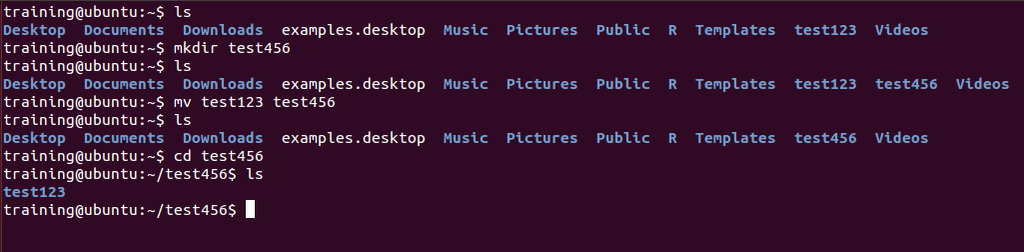

10. `cp` Command helps us to copy the files or any content from one place to another. This copies the content from the source to destination and keeps the content in both the places unlike `mv` command which removes the content from the source folder. Below is an example of how to use the `cp` command:

    ```
    cp [source] [destination]
    example:
    cp NOTICE.txt NOTICE2.txt
    ```

    This example copies the contents in the NOTICE.txt file into NOTICE2.txt. Here NOTICE.txt is the source and NOTICE2.txt is the destination. We can find all the data which is in the NOTICE.txt file in the NOTICE2.txt when we open the NOTICE2.txt using the command as:

    ```
    vi NOTICE2.txt
    ```

- There are many option for using the `cp` command. Some of them are:
  - `-i [interactive]` command prompts before overriding the destination file. Whenever a destination file is being overridden then it prompts us with a question as shown in the below example. Our answer should be `Y` if you want the destination file to be overridden or `N` if you don’t want it to be overridden.

    ```
    training@ubuntu:~/Downloads/hadoop-1.2.1$ cp -i README.txt NOTICE.txt
    cp: overwrite 'NOTICE.txt'? n
    training@ubuntu:~/Downloads/hadoop-1.2.1$ vi NOTICE2.txt
    ```

  - `-b [backup]` command acts as a back up but it does not accept any arguments

    ```
    training@ubuntu:~/Downloads/hadoop-1.2.1$ cp -b NOTICE.txt NOTICE2.txt
    training@ubuntu:~/Downloads/hadoop-1.2.1$ vi NOTICE2.txt
    ```

  - `-r [recursive]` command is used to copy the directories recursively.

    ```
    training@ubuntu:~/Downloads/hadoop-1.2.1$ mkdir 123
    training@ubuntu:~/Downloads/hadoop-1.2.1$ cp -r hadoop-core-1.2.1.jar 123
    training@ubuntu:~/Downloads/hadoop-1.2.1$ cd 123
    training@ubuntu:~/Downloads/hadoop-1.2.1/123$ ls
    hadoop-core-1.2.1.jar
    ```

  - `-n [no clobber]` command is used to prevent the data from overriding

    ```
    training@ubuntu:~/Downloads/hadoop-1.2.1$ cp -n NOTICE.txt NOTICE2.txt
    training@ubuntu:~/Downloads/hadoop-1.2.1$ vi NOTICE2.txt
    ```

  - `-f [force]` command is used when an existing destination can’t be opened it removes it and tries to open it again
  - `-s [symbolic-links]` command is used to make symbolic links to a new file instead of just copying it. Now the file 123.txt will have the same contents as that of NOTICE2.txt

    ```
    training@ubuntu:~/Downloads/hadoop-1.2.1$ cp -s NOTICE2.txt 123.txt
    training@ubuntu:~/Downloads/hadoop-1.2.1$ vi 123.txt
    training@ubuntu:~/Downloads/hadoop-1.2.1$ ls
    123        c++          docs                     hadoop-examples-1.2.1.jar     ivy      LICENSE.txt   NOTICE.txt  src
    123.txt    CHANGES.txt  hadoop-ant-1.2.1.jar     hadoop-minicluster-1.2.1.jar  ivy.xml  logs          README.txt  webapps
    bin        conf         hadoop-client-1.2.1.jar  hadoop-test-1.2.1.jar         lib      NOTICE2.txt   sbin
    build.xml  contrib      hadoop-core-1.2.1.jar    hadoop-tools-1.2.1.jar        libexec  NOTICE2.txt~  share
    ```

  - `-t [target-directory]` command is used to copy all the source arguments into the directory.

    ```
    training@ubuntu:~/Downloads/hadoop-1.2.1$ cp -t 123 NOTICE2.txt
    training@ubuntu:~/Downloads/hadoop-1.2.1$ vi NOTICE2.txt
    training@ubuntu:~/Downloads/hadoop-1.2.1$ cd 123
    training@ubuntu:~/Downloads/hadoop-1.2.1/123$ ls
    hadoop-core-1.2.1.jar  NOTICE2.txt
    ```

  - `-v [verbose]` command is used to describe what action is actually being done. For example we are copying the contents of `hadoop-core-1.2.1.jar` to another directory `123`, these are the following operations we perform

    ```
    training@ubuntu:~/Downloads/hadoop-1.2.1$ cp -v hadoop-core-1.2.1.jar 123
    'hadoop-core-1.2.1.jar' -> '123/hadoop-core-1.2.1.jar'
    ```

11. `sudo` command allows a permitted user to execute a command as the superuser or another user. By default, sudo requires users to authenticate themselves with password. Below is an example of how we use the `sudo` command.

    ```
    training@ubuntu:~$ sudo mkdir directory
    [sudo] password for screenshot:
    training@ubuntu:~$ ls
    Desktop  directory  Documents  Downloads  examples.desktop  Music  Pictures  Public  R  Templates  Videos
    ```

    - In the above example we have tried to create a Directory named `directory` with the `sudo` command. The immediate step is the prompt for the password.
    - Once the password is given the directory is created and it can be verified by giving the `ls` command which produces us with the files and directories as discussed above
12. `kill` is a command that is used in several popular operating systems to send signals to running processes in order to request the termination of the process. Below are some examples of different `kill` commands:
    - `killall`

      ```
      killall -sigkill [process-name]
      ```

    - `pkill` command is same as `killall` but the only thing is `pkill` command allows the use of extended regular expression patterns and other matching criteria. Below is an example:

      ```
      pkill -9 unity
      ```

      Here the command kills all the processes that start with the name `unity`.
    - `pkill` command can also be used to kill usernames. For example

      ```
      pkill -9 -u USERNAME
      ```

- `kill -l` command lists the `kill` signals

```
training@ubuntu:~/Downloads/hadoop-1.2.1$ kill -l
 1) SIGHUP   2) SIGINT   3) SIGQUIT  4) SIGILL   5) SIGTRAP
 6) SIGABRT  7) SIGBUS   8) SIGFPE   9) SIGKILL 10) SIGUSR1
11) SIGSEGV 12) SIGUSR2 13) SIGPIPE 14) SIGALRM 15) SIGTERM
16) SIGSTKFLT   17) SIGCHLD 18) SIGCONT 19) SIGSTOP 20) SIGTSTP
21) SIGTTIN 22) SIGTTOU 23) SIGURG  24) SIGXCPU 25) SIGXFSZ
26) SIGVTALRM   27) SIGPROF 28) SIGWINCH    29) SIGIO   30) SIGPWR
31) SIGSYS  34) SIGRTMIN    35) SIGRTMIN+1  36) SIGRTMIN+2  37) SIGRTMIN+3
38) SIGRTMIN+4  39) SIGRTMIN+5  40) SIGRTMIN+6  41) SIGRTMIN+7  42) SIGRTMIN+8
43) SIGRTMIN+9  44) SIGRTMIN+10 45) SIGRTMIN+11 46) SIGRTMIN+12 47) SIGRTMIN+13
48) SIGRTMIN+14 49) SIGRTMIN+15 50) SIGRTMAX-14 51) SIGRTMAX-13 52) SIGRTMAX-12
53) SIGRTMAX-11 54) SIGRTMAX-10 55) SIGRTMAX-9  56) SIGRTMAX-8  57) SIGRTMAX-7
58) SIGRTMAX-6  59) SIGRTMAX-5  60) SIGRTMAX-4  61) SIGRTMAX-3  62) SIGRTMAX-2
63) SIGRTMAX-1  64) SIGRTMAX
```

- Here we can observe that all the kill signals begin with `SIG` which means `SIGNAL`
13. `head` command reads the first ten lines of a any given file name. The basic syntax of head command is:

    ```
    head [file-name]
    ```

    - Here is an example of using the `head` command

```
LINUX/UNIX@ubuntu:~/Downloads/hadoop-1.2.1$ head LICENSE.txt

                                 Apache License
                           Version 2.0, January 2004
                        http://www.apache.org/licenses/

    TERMS AND CONDITIONS FOR USE, REPRODUCTION, AND DISTRIBUTION

   1. Definitions.

      "License" shall mean the terms and conditions for use, reproduction,
```

- If you want to use the `head` command on multiple files there is an option for that too. You can just give the `head` command followed by filenames for which you want to read the lines. Below is an example of using it.

```
hadoopinstall@ubuntu:~/Downloads/hadoop-1.2.1$ head LICENSE.txt ivy.xml
==> LICENSE.txt <==

                                 Apache License
                           Version 2.0, January 2004
                        http://www.apache.org/licenses/

   TERMS AND CONDITIONS FOR USE, REPRODUCTION, AND DISTRIBUTION

   1. Definitions.

      "License" shall mean the terms and conditions for use, reproduction,

==> ivy.xml <==
<?xml version="1.0" ?>

<!--
   Licensed to the Apache Software Foundation (ASF) under one or more
   contributor license agreements.  See the NOTICE file distributed with
   this work for additional information regarding copyright ownership.
   The ASF licenses this file to You under the Apache License, Version 2.0
   (the "License"); you may not use this file except in compliance with
   the License.  You may obtain a copy of the License at
```

- In the above example we have given a command to read the lines of `LICENSE.txt` and `ivy.xml` file. Its displayed as shown above.
- If we want to retrieve more number of lines than the default 10, then give the hyphen and specify the integer without spaces to get the desired line to be retrieved. Below is an example that shows the usage of the command which produces us with 15 lines.

```
hadoopinstall@ubuntu:~/Downloads/hadoop-1.2.1$ head -15 build.xml
<?xml version="1.0"?>

<!--
   Licensed to the Apache Software Foundation (ASF) under one or more
   contributor license agreements.  See the NOTICE file distributed with
   this work for additional information regarding copyright ownership.
   The ASF licenses this file to You under the Apache License, Version 2.0
   (the "License"); you may not use this file except in compliance with
   the License.  You may obtain a copy of the License at

       http://www.apache.org/licenses/LICENSE-2.0

   Unless required by applicable law or agreed to in writing, software
   distributed under the License is distributed on an "AS IS" BASIS,
   WITHOUT WARRANTIES OR CONDITIONS OF ANY KIND, either express or implied.
```

14. `tail` command allows use to view the last 10 lines of any file. It has the same working as `head` command but the only difference is the `head` command displays the first 10 line where as the `tail` command creates the last 10 lines. Everything else remains the same including the options. The working of `tail` command is as shown below:

    ```
    tail [filenames]
    ```

15. `tar` is used to **Tape Archive** i,e it allows us to convert a large group of files into an archive. This enables us to move the archived file as a single unit which makes the usage easier as every thing will be present at one place.
- Here is an example command to archive a file using `tar` command.

  ```
  tar -cf archive.tar file1 file2
  ```

16. `who` command displays who has logged on into the system. The output will be displayed as follows if the command is given as `who`

    ```
    training@ubuntu:~$ who
    screenshot :0           2014-11-11 16:15 (:0)
    screenshot pts/13       2014-11-11 16:15 (:0)
    training@ubuntu:~$
    ```

17. `cat` command enables us to view the contents in those files. When we write the command `cat [file-name]` it gives us the whole contents present in that file.
    - For example if we want to view the contents of the LICENSE.txt which is present in the Hadoop folder which is in the Downloads folder we give the command `cat LICNSE.txt`. We are produced with the output :

```
training@ubuntu:~/Downloads/hadoop-1.2.1$ cat LICENSE.txt

                                 Apache License
                           Version 2.0, January 2004
                        http://www.apache.org/licenses/

   TERMS AND CONDITIONS FOR USE, REPRODUCTION, AND DISTRIBUTION

   1. Definitions.

      "License" shall mean the terms and conditions for use, reproduction,
      and distribution as defined by Sections 1 through 9 of this document.

      "Licensor" shall mean the copyright owner or entity authorized by
      the copyright owner that is granting the License.

      "Legal Entity" shall mean the union of the acting entity and all
:
```

- There are many other uses of `cat` command. Some of them are:
- It is used to concatenate many number of files together. Here is the example:

  ```
  hadoopinstall@ubuntu:~$ echo 'Hello' > 1
  hadoopinstall@ubuntu:~$ echo 'Welcome to' > 2
  hadoopinstall@ubuntu:~$ echo 'Data Science Lab' > 3
  hadoopinstall@ubuntu:~$ cat 1 2 3 > 4
  hadoopinstall@ubuntu:~$ cat 4
  Hello
  Welcome to
  Data Science Lab
  ```

- `cat` command is also used to copy the files from source to desination

  ```
  hadoopinstall@ubuntu:~$ vi make.txt
  //(data in the file)  i can study the use of CAT command
  hadoopinstall@ubuntu:~$ cat make.txt > make1.txt
  hadoopinstall@ubuntu:~$ cat make1.txt
  i can study the use of CAT command
  ```

18. `clear` Command allows us to clears the screen. If we want to clear the screen after it becomes filled up with the commands then you can simply give the command `clear` which clears the screen by moving all the commands to the upper page. We won’t loose the previous commands and we can also have those by moving the scroll upwards.

    ```
    clear
    ```

19. `rm` command deletes the existing files. It’s similar to the earlier command `rmdir` which deletes the directories and the `rm` command is used to delete the files. Below is the syntax we use to implement the `rm` command:

    ```
    rm [file-name]` the [file-name] is the name of the file that should be deleted.
    ```

    Example of using the `rm` command can be seen below:

    ```
    training@ubuntu:~$ ls
    create.c  Desktop  directory  Documents  Downloads  examples.desktop  Music  Pictures  Public  R  Templates  Videos
    training@ubuntu:~$ rm create.c
    training@ubuntu:~$ ls
    Desktop  directory  Documents  Downloads  examples.desktop  Music  Pictures  Public  R  Templates  Videos
    ```

20. `top` command displays the resources being used by your system. The example of using the `top` command can be seen below. When we intend to stop just enter the letter **q**

```
hadoopinstall@ubuntu:~$ top

top - 13:45:05 up  2:04,  2 users,  load average: 0.23, 0.14, 0.09
Tasks: 312 total,   2 running, 310 sleeping,   0 stopped,   0 zombie
%Cpu(s): 28.9 us, 11.3 sy,  0.0 ni, 42.5 id, 16.9 wa,  0.3 hi,  0.0 si,  0.0 st
KiB Mem:   1010460 total,   940180 used,    70280 free,    68588 buffers
KiB Swap:  1046524 total,    17692 used,  1028832 free.   338844 cached Mem

PID USER      PR  NI    VIRT    RES    SHR S %CPU %MEM     TIME+ COMMAND
3861 hadoopi+  20   0  592080  19156   9480 S 13.7  1.9   0:00.55 unity-scope-loa
 2481 hadoopi+  20   0 1187328  67072  24388 S 11.1  6.6   0:34.82 compiz
 1190 root      20   0  315072  41816  11404 S  5.9  4.1   0:13.11 Xorg
:
```

21. In Linux every single file is associated with timestamps, and every file stores the information of last access time, last modification time and last change time. So, whenever we create new file, access or modify an existing file, the timestamps of that file automatically updated. The `touch` is one such command for Unix/Linux operating systems, that is used to create, change and modify timestamps of a file. Let us now look at the usage of touch command.

    ```
    touch [file-name1] [file-name2] [file-name3]
    ```

- This allows us to create multiple files at a time
- There are different options while using the `touch` command. Now let us have a look into them
  - -a –> Its used to change or update the last access and modification times of a file. This command sets the current time and date on a file. If the above file does not exist, it will create the new empty file with that name. The usage of this command can be done as follows:

    ```
    touch -a [file-name]
    ```

  - -c –> Using the -c option with touch command avoids creating new files. The usage of this command can be done as follows:

    ```
    touch -c [file-name]
    ```

  - -d –> update the access and modification times.
  - -m –> Its used to change the last updated modification time. The usage of this command can be done as follows:

    ```
    touch -m [file-name]
    ```

  - -r –> use the access and modification times of file. The usage of this command can be done as follows:

    ```
    touch -r [file-name1] [file-name2]
    ```

  - -t –> creates a file using a specified time. Its pattern is shown in the example below.

    ```
    touch -t YYMMDDHHMM.SS [file-name]
    ```

22. Whenever if you have been looking for a particular string or pattern in a file, yet have no idea where to start looking for then there is a command you can make use of. It is called `grep`. **grep** is a powerful file pattern searcher that comes equipped on every distribution of Linux. If at all it is not installed on your system, you can easily install it via your package manager. The command we make use of for this purpose is as shown below.

    ```
    sudo apt-get install grep
    ```

    grep is a very useful command to find text or data on the fly when other commands are being used. For example, suppose we want to find a specific file from a ls command, we can use grep. Notice what the following example is doing.

```
ls -l | grep 'metric'
```

23. `history` command produce us with the history. When some one wants to know about the previously used commands then this command can be used

    ```
    training@ubuntu:~$ history
    1  ls
    2  cd Downloads/
    3  ls
    4  cd ..
    5  cd
    6  cd Downloads/
    7  ls
    8  cd
    9  cd ../..
    :
    ```

24. `cal` shows us the calender

    ```
    training@ubuntu:~$ cal
       November 2014
    Su Mo Tu We Th Fr Sa
                   1
     2  3  4  5  6  7  8
     9 10 11 12 13 14 15
    16 17 18 19 20 21 22
    23 24 25 26 27 28 29
    30
    ```

25. `apt` command allows us to automatically and intelligently search, install, update and resolves dependency of packages on Gnu/Linux system from command line.

    ```
    apt (advanced package tool)
    ```

26. `locate` Command is used to search and show the files and directories in every new line. This can be used as follows:

    ```
    locate [file/directory]
    ```

    This produces the output by giving the details of that file and directory.
27. `free` command shows the information about the RAM used and available to be used. This enables the user to manage the files. The usage of `free` command is shown below:

    ```
    training@ubuntu:~$ free
             total       used       free     shared    buffers     cached
    Mem:       1010460     902112     108348       7548     126016     212432
    -/+ buffers/cache:     563664     446796
    Swap:      1046524      14064    1032460
    training@ubuntu:~$
    ```

28. `passwd` command that enables the user to change the password. When the user feels the present password is too short then he can change it using this command. The process for using this command and changing the password is shown below:

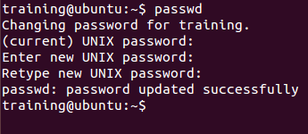

29. We can connect multiple commands together with what are called `pipes` represented with the symbol `|`. With pipes, the standard output of one command is fed into the standard input of another.

    ```
    [me@linuxbox me]$ ls -l | book
    ```

    In this example, the output of the ls command is fed into book. By using the “| less” , you can make any command have scrolling output
30. `>` symbol is used to send information somewhere from one place to another. The following example gets the head of file1.txt and creates a new file2.txt to save the output.

```
  head file1.txt > file2.txt
```

- The more detailed examples are shown in the `cat` command
31. `exit` command that is used to come out of the terminal

    ```
    exit
    ```

### Stopping data science virtual machine

Never close the VMWare machine with the `x` button as we generally do for closing other things, instead always shut down properly to save all the work done without any failure.

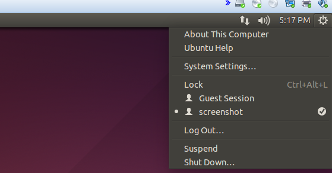

[figure not shown]

Back to top

##### You can find the complete documentation of all the things we have done now, in the Data Science Tools folder which is on the desktop of the lab machines. You can open the LinuxCommands.html file for the complete documentation.